# The ATA tax — master notebook

**One question:** how much of a card's 17Lands win rate is *real strength* versus *inflation from being picked late*? A card taken later was acquired more cheaply, so the deck around it is better — an "ATA tax" on the printed stats. This notebook reproduces the whole investigation end-to-end from `lib17`; the exhaustive catalog of confounders, hypotheses, and the methods retrospective lives in **`NOTES.md`** (this notebook stays runnable, the notes hold the depth).

Self-contained: every figure is computed inline from `data/`; nothing here reads `out/`, so the output directory can be cleared freely.

**Contents** 0. Setup

1. Format context (general primitives — top cards, archetypes, movers)
2. The metrics and their biases
3. The answer: the as-picked design
4. The weekly panel, and why it is *not* a tax estimator
5. GIH = GNS + IIH: deck vs card, and the mover attribution
6. Card vs archetype (gold vs flexible)
7. Worked example: Aang priced like Teferi
8. Synthesis

```python
import sys
from pathlib import Path
sys.path.insert(0, str(Path.cwd().parent))
import numpy as np
import pandas as pd
import matplotlib.pyplot as plt
from lib17 import data, metrics, analysis, weekly, overview
from lib17 import htmlfmt as H
plt.rcParams.update(H.MPL_STYLE)
pd.set_option("display.width", 200)
FORMATS = ["sos", "fin", "tla", "cube"]
RETAIL = ["sos", "fin", "tla"]
NAMES = {"sos": "SOS", "fin": "FIN", "tla": "TLA", "cube": "Powered Cube"}
CRIM, INK, FADE, GOLD = H.CRIM, H.INK, H.FADE, "#9a7b2d"
```

## 1. Format context (general-purpose primitives)

These concepts are reusable for any 17Lands format read, independent of the tax question: top cards (overall and by rarity), the archetype metagame, and the biggest re-pricings — each available whole-format and week by week (`lib17.overview`).

```python
for tag in RETAIL:
    print(f"\n=== {NAMES[tag]}: top commons ===")
    display(overview.top_cards(tag, rarity="common", n=6))
```

```
=== SOS: top commons ===
```

|  | name | rarity | ata | play_rate | gih_wr | gp_wr | n_gih |
| --- | --- | --- | --- | --- | --- | --- | --- |
| 0 | Elite Interceptor | common | 4.984890 | 0.867035 | 0.596481 | 0.582622 | 73258.0 |
| 1 | Pursue the Past | common | 7.447501 | 0.677818 | 0.594492 | 0.576615 | 55444.0 |
| 2 | Rubble Rouser | common | 6.499974 | 0.787303 | 0.583714 | 0.566814 | 66058.0 |
| 3 | Unsubtle Mockery | common | 4.627276 | 0.923963 | 0.580187 | 0.559240 | 75081.0 |
| 4 | Ajani's Response | common | 6.070466 | 0.835457 | 0.580089 | 0.570436 | 59865.0 |
| 5 | Render Speechless | common | 8.921714 | 0.503555 | 0.579450 | 0.574230 | 35085.0 |

```
=== FIN: top commons ===
```

|  | name | rarity | ata | play_rate | gih_wr | gp_wr | n_gih |
| --- | --- | --- | --- | --- | --- | --- | --- |
| 0 | White Auracite | common | 3.852996 | 0.864595 | 0.595552 | 0.571638 | 76890.0 |
| 1 | Combat Tutorial | common | 6.118016 | 0.828918 | 0.591448 | 0.566638 | 101539.0 |
| 2 | Town Greeter | common | 6.512310 | 0.785225 | 0.591257 | 0.566395 | 81709.0 |
| 3 | Dragoon's Wyvern | common | 5.023563 | 0.869194 | 0.588941 | 0.567151 | 115937.0 |
| 4 | Sephiroth's Intervention | common | 3.215379 | 0.918975 | 0.588862 | 0.561106 | 93353.0 |
| 5 | Thunder Magic | common | 3.766931 | 0.874549 | 0.586228 | 0.564529 | 88863.0 |

```
=== TLA: top commons ===
```

|  | name | rarity | ata | play_rate | gih_wr | gp_wr | n_gih |
| --- | --- | --- | --- | --- | --- | --- | --- |
| 0 | Lost Days | common | 6.206157 | 0.859446 | 0.588596 | 0.572319 | 86516.0 |
| 1 | Firebending Lesson | common | 3.923436 | 0.871051 | 0.586677 | 0.565033 | 67705.0 |
| 2 | It'll Quench Ya! | common | 6.413388 | 0.831017 | 0.586043 | 0.568552 | 70790.0 |
| 3 | Watery Grasp | common | 6.486769 | 0.806108 | 0.582416 | 0.569036 | 71612.0 |
| 4 | Forecasting Fortune Teller | common | 4.948498 | 0.884960 | 0.578986 | 0.565228 | 83116.0 |
| 5 | Path to Redemption | common | 4.621295 | 0.889645 | 0.578444 | 0.571249 | 60483.0 |

**The archetype metagame** — share and win rate over the whole format:

```python
for tag in RETAIL:
    print(f"\n=== {NAMES[tag]} ===")
    display(overview.archetype_summary(tag))
```

```
=== SOS ===
```

|  | arch | share_% | win_rate | games |
| --- | --- | --- | --- | --- |
| 0 | WR | 26.048100 | 0.576674 | 120113.0 |
| 1 | UR | 23.722241 | 0.544182 | 109388.0 |
| 2 | WB | 21.771556 | 0.577002 | 100393.0 |
| 3 | BG | 15.916464 | 0.545085 | 73394.0 |
| 4 | UG | 12.090779 | 0.550607 | 55753.0 |

```
=== FIN ===
```

|  | arch | share_% | win_rate | games |
| --- | --- | --- | --- | --- |
| 0 | UR | 16.165931 | 0.573427 | 104526.0 |
| 1 | BG | 13.591470 | 0.567399 | 87880.0 |
| 2 | UB | 12.135197 | 0.555185 | 78464.0 |
| 3 | WU | 11.701841 | 0.558775 | 75662.0 |
| 4 | WB | 9.769372 | 0.566055 | 63167.0 |
| 5 | WR | 9.541404 | 0.568995 | 61693.0 |
| 6 | BR | 7.961713 | 0.551642 | 51479.0 |
| 7 | UG | 7.631979 | 0.558757 | 49347.0 |
| 8 | WG | 6.755833 | 0.561948 | 43682.0 |
| 9 | RG | 4.745260 | 0.538198 | 30682.0 |

```
=== TLA ===
```

|  | arch | share_% | win_rate | games |
| --- | --- | --- | --- | --- |
| 0 | WU | 17.786529 | 0.571175 | 77050.0 |
| 1 | UB | 14.332411 | 0.565787 | 62087.0 |
| 2 | UR | 11.793819 | 0.567919 | 51090.0 |
| 3 | WG | 11.271189 | 0.573383 | 48826.0 |
| 4 | WR | 10.991406 | 0.573382 | 47614.0 |
| 5 | WB | 8.318463 | 0.559456 | 36035.0 |
| 6 | UG | 6.681779 | 0.551114 | 28945.0 |
| 7 | BG | 6.602369 | 0.561134 | 28601.0 |
| 8 | BR | 6.265337 | 0.540142 | 27141.0 |
| 9 | RG | 5.956698 | 0.555108 | 25804.0 |

**Archetype trends, week by week** — share (left) and win rate vs format (right). This is the seasonal movement that will turn out to drive the weekly re-pricing panel (§4).

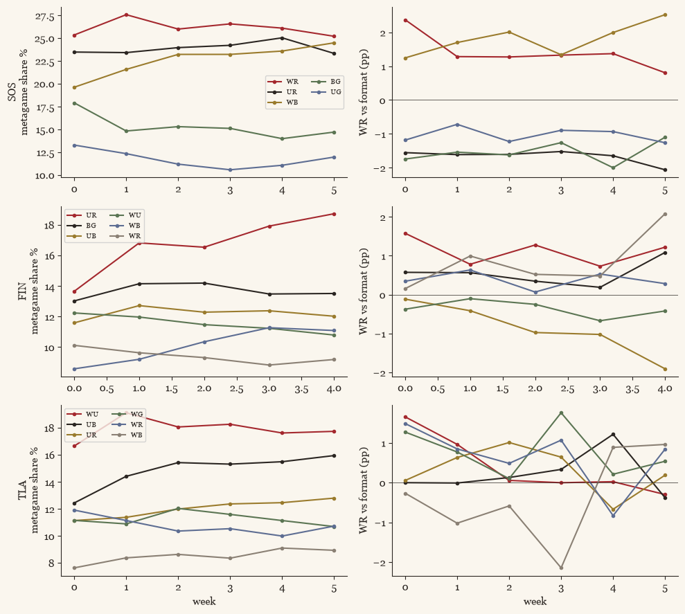

```python
fig, axes = plt.subplots(len(RETAIL), 2, figsize=(10, 3 * len(RETAIL)))
for row, tag in zip(axes, RETAIL):
    t = overview.archetype_trends(tag)
    top = t.groupby("arch").n.sum().nlargest(6).index
    pal = [CRIM, INK, GOLD, "#5b7553", "#5d6d92", FADE]
    for arch, c in zip(top, pal):
        g = t[t.arch == arch].sort_values("wk")
        row[0].plot(g.wk, g.share * 100, "-o", ms=3, color=c, label=arch)
        row[1].plot(g.wk, g.rel_wr * 100, "-o", ms=3, color=c)
    row[0].set_ylabel(f"{NAMES[tag]}\nmetagame share %"); row[1].axhline(0, color=INK, lw=.5)
    row[1].set_ylabel("WR vs format (pp)"); row[0].legend(fontsize=7, ncol=2)
for ax in axes[-1]:
    ax.set_xlabel("week")
plt.tight_layout(); plt.show()
```

**The biggest movers** — cards the community re-priced most, split into those taken progressively **earlier** (discovered) and **later** (faded). Each row shows GIH win rate (vs format) before/after, the card's most-played archetypes and shares (`mix`), and that top archetype's own win-rate movement over the season (`top arch ΔWR`) — so you can see whether the card moved *with its deck*. (Most do: foreshadows §5.)

```python
for tag in RETAIL:
    print(f"\n=== {NAMES[tag]}: taken EARLIER (discovered) ===")
    display(overview.biggest_movers(tag, n=10, direction="up"))
    print(f"=== {NAMES[tag]}: taken LATER (faded) ===")
    display(overview.biggest_movers(tag, n=10, direction="down"))
```

```
=== SOS: taken EARLIER (discovered) ===
```

|  | name | ata_first | ata_last | ata_move | GIH early | GIH late | mix (top archetypes) | ΔGIH | top arch ΔWR |
| --- | --- | --- | --- | --- | --- | --- | --- | --- | --- |
| 0 | Arcane Omens | 8.6 | 4.5 | -4.0 | 4.2 | 4.2 | UR 20% / URG 17% / UBG 13% | 0.0 | -0.6 |
| 1 | Potioner's Trove | 7.6 | 4.6 | -3.8 | 1.1 | 1.6 | UR 30% / URG 19% / UG 12% | 0.5 | -0.6 |
| 2 | Brush Off | 8.0 | 5.1 | -2.9 | 1.3 | 2.5 | UR 49% / UG 19% / URG 16% | 1.2 | -0.6 |
| 3 | Snarl Song | 5.8 | 3.3 | -2.7 | 5.4 | 5.1 | URG 28% / UG 21% / UR 16% | -0.3 | 0.7 |
| 4 | Divergent Equation | 7.3 | 5.0 | -2.3 | 1.7 | 3.4 | UR 47% / URG 17% / UG 15% | 1.7 | -0.6 |
| 5 | Render Speechless | 9.7 | 7.3 | -2.3 | 1.3 | 1.3 | WB 87% / WBR 5% / WBG 3% | 0.0 | 1.5 |
| 6 | Pursue the Past | 8.5 | 6.8 | -2.0 | 3.4 | 2.2 | WR 73% / WUR 12% / UR 5% | -1.2 | -1.4 |
| 7 | Ajani's Response | 6.9 | 5.4 | -1.8 | 1.7 | 1.0 | WR 40% / WB 34% / WUR 8% | -0.7 | -1.4 |
| 8 | Zealous Lorecaster | 10.0 | 8.5 | -1.8 | -1.6 | -1.8 | UR 40% / WR 27% / URG 13% | -0.2 | -0.6 |
| 9 | Cost of Brilliance | 8.7 | 7.0 | -1.8 | 0.9 | 2.8 | WB 64% / BG 26% / WBR 3% | 1.9 | 1.5 |

```
=== SOS: taken LATER (faded) ===
```

|  | name | ata_first | ata_last | ata_move | GIH early | GIH late | mix (top archetypes) | ΔGIH | top arch ΔWR |
| --- | --- | --- | --- | --- | --- | --- | --- | --- | --- |
| 0 | Abstract Paintmage | 6.4 | 9.4 | 3.6 | -5.7 | -7.2 | UR 83% / URG 10% / WUR 4% | -1.5 | -0.6 |
| 1 | Encouraging Aviator | 6.6 | 9.2 | 3.4 | -5.9 | -7.7 | UR 50% / UG 32% / URG 8% | -1.8 | -0.6 |
| 2 | Arnyn, Deathbloom Botanist | 6.1 | 8.6 | 3.1 | -5.9 | -3.5 | BG 62% / WB 28% / UBG 4% | 2.4 | 0.9 |
| 3 | Blazing Firesinger | 7.3 | 9.6 | 2.8 | -6.4 | -6.9 | UR 57% / WR 28% / URG 7% | -0.5 | -0.6 |
| 4 | Orysa, Tide Choreographer | 6.5 | 8.8 | 2.7 | -3.2 | -0.8 | UR 36% / UG 34% / URG 13% | 2.4 | -0.6 |
| 5 | Ennis, Debate Moderator | 6.5 | 8.6 | 2.5 | -6.1 | -7.1 | WR 50% / WB 42% / WBR 4% | -1.0 | -1.4 |
| 6 | Campus Composer | 5.5 | 7.5 | 2.3 | -2.3 | -2.3 | UR 52% / UG 24% / URG 12% | 0.0 | -0.6 |
| 7 | Harmonized Trio | 3.4 | 5.4 | 2.3 | -2.8 | -3.2 | UR 44% / UG 30% / URG 12% | -0.4 | -0.6 |
| 8 | Graduation Day | 7.1 | 8.9 | 2.3 | -4.9 | -5.2 | WB 73% / WR 22% / WBR 3% | -0.3 | 1.5 |
| 9 | Nita, Forum Conciliator | 4.6 | 6.7 | 2.3 | -5.0 | -4.4 | WB 78% / WBG 6% / BG 5% | 0.6 | 1.5 |

```
=== FIN: taken EARLIER (discovered) ===
```

|  | name | ata_first | ata_last | ata_move | GIH early | GIH late | mix (top archetypes) | ΔGIH | top arch ΔWR |
| --- | --- | --- | --- | --- | --- | --- | --- | --- | --- |
| 0 | Sidequest: Card Collection | 8.3 | 4.7 | -3.5 | 2.9 | 1.4 | UR 35% / UB 24% / UG 11% | -1.5 | -0.2 |
| 1 | Sorceress's Schemes | 9.7 | 6.4 | -3.4 | 1.8 | 0.6 | UR 58% / BR 19% / UBR 8% | -1.2 | -0.2 |
| 2 | Combat Tutorial | 7.4 | 4.7 | -2.7 | 2.8 | 2.6 | UR 30% / UB 22% / WU 18% | -0.2 | -0.2 |
| 3 | Sahagin | 8.0 | 5.6 | -2.4 | 1.8 | 2.1 | UR 48% / UB 24% / WU 10% | 0.3 | -0.2 |
| 4 | Phantom Train | 9.1 | 7.4 | -2.2 | -1.6 | -1.8 | WB 44% / BR 20% / UB 14% | -0.2 | 0.1 |
| 5 | Dreams of Laguna | 8.1 | 6.1 | -2.2 | 1.9 | 1.1 | UR 38% / UB 24% / WU 12% | -0.8 | -0.2 |
| 6 | Resentful Revelation | 8.4 | 6.4 | -2.1 | 2.0 | 1.3 | BG 31% / UB 24% / BR 17% | -0.7 | 0.1 |
| 7 | Fire Magic | 5.9 | 4.3 | -1.7 | 0.8 | 1.2 | UR 47% / BR 15% / RG 9% | 0.4 | -0.2 |
| 8 | Scorpion Sentinel | 9.0 | 7.3 | -1.7 | -0.4 | -0.2 | UR 26% / WU 23% / UB 22% | 0.2 | -0.2 |
| 9 | Black Mage's Rod | 6.5 | 5.4 | -1.7 | -0.6 | -0.0 | BR 28% / UB 28% / WB 21% | 0.6 | -0.7 |

```
=== FIN: taken LATER (faded) ===
```

|  | name | ata_first | ata_last | ata_move | GIH early | GIH late | mix (top archetypes) | ΔGIH | top arch ΔWR |
| --- | --- | --- | --- | --- | --- | --- | --- | --- | --- |
| 0 | Chocobo Racetrack | 5.0 | 8.2 | 3.5 | -4.6 | -5.8 | RG 23% / UG 22% / BG 20% | -1.2 | 0.2 |
| 1 | Vaan, Street Thief | 4.1 | 7.1 | 3.3 | -9.3 | -9.9 | UR 26% / WR 25% / BR 21% | -0.6 | -0.2 |
| 2 | Summoner's Grimoire | 4.2 | 6.9 | 2.9 | -4.8 | -6.5 | BG 25% / UG 19% / WG 16% | -1.7 | 0.1 |
| 3 | Tidus, Blitzball Star | 6.7 | 9.3 | 2.9 | -5.3 | -5.1 | WU 88% / WUB 4% / WUR 2% | 0.2 | -0.2 |
| 4 | Ishgard, the Holy See | 4.9 | 7.3 | 2.8 | -2.9 | -3.2 | WU 31% / WB 21% / WR 19% | -0.3 | -0.2 |
| 5 | Jumbo Cactuar | 4.1 | 6.8 | 2.7 | -7.1 | -7.0 | BG 28% / RG 20% / UG 17% | 0.1 | 0.1 |
| 6 | Tifa Lockhart | 3.6 | 6.2 | 2.6 | -6.9 | -6.0 | RG 27% / WG 21% / BG 20% | 0.9 | 0.2 |
| 7 | Genji Glove | 4.5 | 6.9 | 2.4 | -7.2 | -4.8 | WR 26% / WU 14% / WB 10% | 2.4 | 0.8 |
| 8 | Sidequest: Catch a Fish | 8.5 | 10.6 | 2.4 | -5.7 | -4.5 | WU 29% / WB 27% / WR 19% | 1.2 | -0.2 |
| 9 | Lindblum, Industrial Regency | 4.5 | 6.7 | 2.4 | -3.6 | -2.8 | UR 38% / BR 26% / WR 13% | 0.8 | -0.2 |

```
=== TLA: taken EARLIER (discovered) ===
```

|  | name | ata_first | ata_last | ata_move | GIH early | GIH late | mix (top archetypes) | ΔGIH | top arch ΔWR |
| --- | --- | --- | --- | --- | --- | --- | --- | --- | --- |
| 0 | Barrels of Blasting Jelly | 10.0 | 7.8 | -2.7 | -2.0 | -0.8 | UB 11% / WU 11% / UR 9% | 1.2 | -0.9 |
| 1 | Fire Nation Warship | 8.5 | 6.5 | -2.2 | 0.5 | 2.1 | UB 18% / WU 13% / WB 11% | 1.6 | -0.9 |
| 2 | Compassionate Healer | 6.9 | 5.2 | -2.0 | 1.2 | -1.2 | WU 34% / WG 22% / WR 21% | -2.4 | -2.0 |
| 3 | Lost Days | 7.2 | 5.4 | -1.9 | 2.6 | 1.9 | WU 25% / UB 22% / UR 20% | -0.7 | -2.0 |
| 4 | Waterbending Lesson | 7.7 | 6.1 | -1.9 | 0.3 | 0.4 | UB 24% / WU 23% / UR 21% | 0.1 | -0.9 |
| 5 | Watery Grasp | 7.6 | 5.8 | -1.9 | 2.0 | 1.9 | WU 30% / UB 25% / UR 17% | -0.1 | -2.0 |
| 6 | Crescent Island Temple | 9.6 | 8.6 | -1.8 | -2.8 | -2.1 | URG 15% / UR 8% / WURG 7% | 0.7 | 1.3 |
| 7 | Kyoshi Battle Fan | 9.3 | 7.8 | -1.8 | -0.2 | -0.4 | WU 24% / UB 13% / WR 12% | -0.2 | -2.0 |
| 8 | Octopus Form | 8.7 | 6.8 | -1.7 | 1.4 | -0.1 | WU 27% / UR 23% / UB 21% | -1.5 | -2.0 |
| 9 | Otter-Penguin | 9.8 | 8.2 | -1.7 | -1.0 | -1.3 | UB 35% / WU 28% / UR 23% | -0.3 | -0.9 |

```
=== TLA: taken LATER (faded) ===
```

|  | name | ata_first | ata_last | ata_move | GIH early | GIH late | mix (top archetypes) | ΔGIH | top arch ΔWR |
| --- | --- | --- | --- | --- | --- | --- | --- | --- | --- |
| 0 | Leaves from the Vine | 7.7 | 10.4 | 3.0 | -3.9 | -4.2 | WG 21% / BG 21% / UG 18% | -0.3 | -0.6 |
| 1 | Zhao, Ruthless Admiral | 7.5 | 10.0 | 2.9 | -5.8 | -5.2 | BR 42% / WB 23% / UB 12% | 0.6 | 0.2 |
| 2 | Fire Nation Attacks | 5.8 | 8.3 | 2.9 | -1.6 | -0.3 | UR 32% / WR 23% / BR 21% | 1.3 | -0.3 |
| 3 | Buzzard-Wasp Colony | 7.3 | 9.6 | 2.6 | -5.5 | -2.1 | WB 33% / BG 23% / UB 23% | 3.4 | 0.8 |
| 4 | Cruel Administrator | 6.9 | 9.1 | 2.6 | -4.3 | -5.8 | BR 71% / UBR 9% / WBR 6% | -1.5 | 0.2 |
| 5 | The Last Agni Kai | 4.0 | 6.2 | 2.4 | -6.8 | -8.0 | RG 21% / WR 19% / BR 19% | -1.2 | 0.9 |
| 6 | Combustion Man | 5.6 | 7.7 | 2.4 | -4.1 | -3.0 | BR 23% / WR 22% / UR 22% | 1.1 | 0.2 |
| 7 | Uncle Iroh | 6.0 | 8.0 | 2.2 | -3.8 | -1.8 | RG 25% / URG 20% / UR 17% | 2.0 | 0.9 |
| 8 | Sparring Dummy | 8.0 | 9.8 | 2.2 | -4.2 | -3.5 | UG 22% / BG 17% / URG 16% | 0.7 | 1.6 |
| 9 | Zuko, Exiled Prince | 5.2 | 7.0 | 2.0 | -3.9 | -2.0 | UR 23% / BR 23% / WR 21% | 1.9 | -0.3 |

## 2. The metrics and their biases

17Lands metrics and the biases to keep in mind (full table in `NOTES.md §2`). The load-bearing identity is **`GIH = GNS + IIH`**: GNS WR (never-seen) is pure deck context (the control group), IIH (= GIH − GNS) is the card's own in-hand value, deck-cancelled by construction. The ATA tax is a *deck-quality* effect, so it should live in **GNS**, not IIH — a prediction we test in §3.

```python
print(metrics.__doc__[:1100])
```

```
17Lands metric definitions, their known biases, and corrected measures.

The raw metrics (per card):
  GP WR   win rate of games with the card maindecked. Deck-level; per-card
          signal is diluted ~1/23, but it's the only stat that charges
          build-arounds their deckbuilding tax.
  GIH WR  win rate of games where the card reached hand. BIAS: oversamples
          long games (inflates slow/blue decks' cards ~3-5pp).
  OH WR   win rate with the card in the kept opening seven. BIAS: kept-hand
          mulligan selection + the early-game slice penalize expensive and
          scaling cards monotonically in mana value (~3.7pp spread MV0->6+).
  GD WR   drawn after the opener. BIAS: long-game oversampling, anti-aggro.
  GNS WR  card maindecked but never seen — the control group: deck context
          with zero card contribution. BIAS: oversamples SHORT games (fewer
          cards seen), inflating fast decks' context; corrected here by
          reweighting turn strata to the format distribution.
  ALSA/ATA average last-seen / actually-taken pick. ALSA is compressed by
```

## 3. The answer: the as-picked design

Compare the *same card* taken at pick 3 vs pick 10 across simultaneous drafts, card fixed effects (`lib17.analysis`, from the public logs). This holds the season/discovery state fixed and makes the pick exogenous to that draft's result — the one estimator that is stable across metric, units, and controls. Slopes are pp of win rate **per taken-at pick**, card-clustered SEs.

```python
rows = []
for tag in FORMATS:
    s = analysis.aspicked_slopes(tag)
    rows.append({"format": NAMES[tag],
                 **{m: round(s[m][0], 3) for m in ["gp_wr", "gih_wr", "oh_wr", "gns_wr"]},
                 "maindeck/pick": round(s["md_rate"][0], 2)})
display(pd.DataFrame(rows))
```

|  | format | gp_wr | gih_wr | oh_wr | gns_wr | maindeck/pick |
| --- | --- | --- | --- | --- | --- | --- |
| 0 | SOS | 0.131 | 0.135 | 0.095 | 0.154 | -4.19 |
| 1 | FIN | 0.096 | 0.100 | 0.082 | 0.124 | -4.20 |
| 2 | TLA | 0.091 | 0.075 | 0.058 | 0.121 | -4.22 |
| 3 | Powered Cube | 0.084 | 0.074 | 0.052 | 0.089 | -3.61 |

Two facts: **GNS carries the largest slope** in every format — a card taken later wins more *in games it never appears in*, which can only be the surrounding deck. That is the tax, and it correctly shows up in deck quality. And **maindeck probability falls ~4pp per pick** — the deployment filter.

The premium is **front-loaded** (most of it in the first picks), and the deployment filter is brutal for narrow cards:

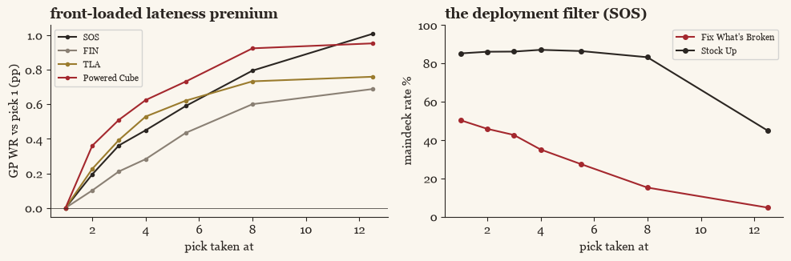

```python
def aspicked_frame(tag):
    a = data.aspicked(tag)
    return a

fig, axes = plt.subplots(1, 2, figsize=(10, 3.4))
for tag, c in zip(FORMATS, [INK, FADE, GOLD, CRIM]):
    a = aspicked_frame(tag)
    curve, _, _ = analysis.within_card(a, "gp_wr", "n_gp")
    curve = (curve - curve.iloc[0]) * 100
    axes[0].plot(curve.index, curve.values, "-o", ms=3, color=c, label=NAMES[tag])
axes[0].axhline(0, color=INK, lw=.5); axes[0].legend(fontsize=8)
axes[0].set_xlabel("pick taken at"); axes[0].set_ylabel("GP WR vs pick 1 (pp)")
axes[0].set_title("front-loaded lateness premium", loc="left", fontweight="bold")
a = aspicked_frame("sos")
for nm, c in [("Fix What's Broken", CRIM), ("Stock Up", INK)]:
    g = a[a.name == nm].sort_values("pick_mid")
    axes[1].plot(g.pick_mid, g.md_rate * 100, "-o", ms=4, color=c, label=nm)
axes[1].set_xlabel("pick taken at"); axes[1].set_ylabel("maindeck rate %"); axes[1].set_ylim(0, 100)
axes[1].legend(fontsize=8); axes[1].set_title("the deployment filter (SOS)", loc="left", fontweight="bold")
plt.tight_layout(); plt.show()
```

## 4. The weekly panel, and why it is *not* a tax estimator

The other design — `WR ~ ALSA + card FE + week FE` on weekly stat tables, identified by the community re-pricing cards — reads 2–5× higher and is unstable across metric / units / card subset. A real tax does not move with bookkeeping.

```python
KAPPA = metrics.KAPPA  # within-card dATA/dALSA = 1.546
inst = []
for tag in RETAIL:
    a = analysis.weekly_panel(NAMES[tag], "gp_wr", "n_gp")[0]
    inst.append({"format": NAMES[tag], "GP panel /ALSA-pick": round(a, 2),
                 "/ATA-pick (÷κ)": round(a / KAPPA, 2),
                 "as-picked GP (logs)": round(analysis.aspicked_slopes(tag)["gp_wr"][0], 2)})
display(pd.DataFrame(inst))
```

|  | format | GP panel /ALSA-pick | /ATA-pick (÷κ) | as-picked GP (logs) |
| --- | --- | --- | --- | --- |
| 0 | SOS | 0.35 | 0.23 | 0.13 |
| 1 | FIN | 0.42 | 0.27 | 0.10 |
| 2 | TLA | 0.67 | 0.43 | 0.09 |

**Why it reads high: the archetype tide.** The panel has *week* fixed effects but no *archetype* fixed effects, so an archetype's own seasonal win-rate arc survives. Re-net each card's weekly win rate against *its own archetype's* weekly win rate (instead of the format), and the slope collapses — proving the panel is reading the deck underneath the card, not the card.

```python
def panel_vs_archetype(tag):
    w, windows = weekly.weekly_panel(tag)
    w = w[w.ata.notna()].copy()
    modal = data.card_stats(tag).set_index("name").modal_deck
    ab = weekly.arch_baseline(tag, windows)[["arch", "t", "arch_rel"]]
    w["arch"] = w.name.map(modal)
    w = w.merge(ab, on=["arch", "t"], how="left")
    p = w.dropna(subset=["ata", "gih_wr_rel", "arch_rel", "n_gih"]).copy()
    k = p.groupby("name").window.nunique(); p = p[p.name.isin(k[k >= 3].index)].reset_index(drop=True)
    p["net"] = p.gih_wr_rel - p.arch_rel
    p["xr"] = weekly.residualize(p, "ata"); p["yf"] = weekly.residualize(p, "gih_wr_rel")
    p["yn"] = weekly.residualize(p, "net")
    return weekly.panel_slope(p, "xr", "yf"), weekly.panel_slope(p, "xr", "yn")

rows = []
for tag in RETAIL:
    vf, vn = panel_vs_archetype(tag)
    rows.append({"format": NAMES[tag], "GIH~ATA slope vs format": round(vf, 2),
                 "vs OWN archetype": round(vn, 2)})
display(pd.DataFrame(rows))
```

|  | format | GIH~ATA slope vs format | vs OWN archetype |
| --- | --- | --- | --- |
| 0 | SOS | 0.03 | -0.23 |
| 1 | FIN | 0.17 | -0.05 |
| 2 | TLA | 0.38 | -0.19 |

```python
w, windows = weekly.weekly_panel("sos"); w = w[w.ata.notna()]
_, allf = weekly.find_movers(w, "sos")
movers = allf[(allf.move.abs() >= 1.25) & (allf.rho.abs() >= 0.6)].index
p = w.dropna(subset=["ata", "gih_wr_rel", "n_gih"]).copy()
k = p.groupby("name").window.nunique(); p = p[p.name.isin(k[k >= 3].index)].reset_index(drop=True)
p["xr"] = weekly.residualize(p, "ata"); p["yr"] = weekly.residualize(p, "gih_wr_rel")
g = p[~p.name.isin(movers)].groupby("name").apply(
    lambda d: pd.Series({"N": (d.n_gih * d.xr * d.yr).sum(), "D": (d.n_gih * d.xr ** 2).sum()}),
    include_groups=False)
g["slope"] = g.N / g.D * 100
pooled = g.N.sum() / g.D.sum() * 100
jk = {f"drop top {kk}": round(g.drop(g.nlargest(kk, "D").index).pipe(lambda x: x.N.sum() / x.D.sum() * 100), 2)
      for kk in [0, 1, 3, 5]}
print(f"non-mover pooled slope {pooled:+.2f} | median per-card {g.slope.median():+.2f} | "
      f"% positive {(g.slope > 0).mean():.0%}")
print("jackknife:", jk)
print("the 5 leverage cards (discovery co-trends):", list(g.nlargest(5, "D").index))
```

```
non-mover pooled slope +0.14 | median per-card -0.02 | % positive 50%
jackknife: {'drop top 0': np.float64(0.14), 'drop top 1': np.float64(0.07), 'drop top 3': np.float64(0.06), 'drop top 5': np.float64(0.06)}
the 5 leverage cards (discovery co-trends): ['Pursue the Past', 'Tome Blast', 'Burrog Barrage', 'Sundering Archaic', 'Unsubtle Mockery']
```

## 5. GIH = GNS + IIH: deck vs card, and the mover attribution

For each format's ten biggest movers, split the season GIH change into **deck (ΔGNS)** — pure deck context, well sampled — and **individual (ΔIIH)** — the card's in-hand lift over its own decks. We don't lean on a precise individual number: the deck channel is the trustworthy one, and individual counts only when it clears twice its sampling noise.

```python
def attribute_movers(tag, k=10):
    w, _ = weekly.weekly_panel(tag)
    w = w[w.ata.notna() & w.gns_wr.notna() & (w.n_gns >= 50)]
    _, allf = weekly.find_movers(w, tag, min_gih=800)
    top = allf.reindex(allf.move.abs().sort_values(ascending=False).index).head(k)
    rows = []
    for name in top.index:
        g = w[w.name == name]
        if g.t.nunique() < 4:
            continue
        s = weekly.season_split(g)
        if abs(s["d_iih"]) < 2 * s["se_iih"]:
            v = "deck-driven"
        elif abs(s["d_iih"]) > abs(s["d_gns"]):
            v = "individual"
        else:
            v = "mixed"
        rows.append({"card": name, "ATA move": round(top.loc[name, "move"], 1),
                     "ΔGIH": round(s["d_gih"], 1), "deck ΔGNS": round(s["d_gns"], 1),
                     "indiv ΔIIH": round(s["d_iih"], 1), "±se": round(s["se_iih"], 1),
                     "verdict": v})
    return pd.DataFrame(rows)

tally = {"deck-driven": 0, "individual": 0, "mixed": 0}
for tag in RETAIL:
    df = attribute_movers(tag)
    for v in df.verdict:
        tally[v] += 1
    print(f"\n=== {NAMES[tag]} ===")
    display(df)
print("\nTALLY across the three sets:", tally)
```

```
=== SOS ===
```

|  | card | ATA move | ΔGIH | deck ΔGNS | indiv ΔIIH | ±se | verdict |
| --- | --- | --- | --- | --- | --- | --- | --- |
| 0 | Arcane Omens | -4.0 | -1.8 | -1.7 | -0.1 | 0.9 | deck-driven |
| 1 | Potioner's Trove | -3.8 | 0.5 | -0.3 | 0.8 | 0.7 | deck-driven |
| 2 | Abstract Paintmage | 3.6 | -1.5 | -0.6 | -0.8 | 1.8 | deck-driven |
| 3 | Encouraging Aviator | 3.4 | -1.8 | -1.8 | 0.0 | 1.7 | deck-driven |
| 4 | Arnyn, Deathbloom Botanist | 3.1 | 2.4 | 1.5 | 0.9 | 1.8 | deck-driven |
| 5 | Brush Off | -2.9 | 1.2 | -0.6 | 1.8 | 0.9 | individual |
| 6 | Blazing Firesinger | 2.8 | -0.5 | -0.3 | -0.1 | 1.7 | deck-driven |
| 7 | Snarl Song | -2.7 | 0.3 | -2.0 | 2.3 | 0.8 | individual |
| 8 | Orysa, Tide Choreographer | 2.7 | 2.3 | -1.3 | 3.7 | 1.6 | individual |
| 9 | Ennis, Debate Moderator | 2.5 | -1.0 | 0.7 | -1.7 | 1.6 | deck-driven |

```
=== FIN ===
```

|  | card | ATA move | ΔGIH | deck ΔGNS | indiv ΔIIH | ±se | verdict |
| --- | --- | --- | --- | --- | --- | --- | --- |
| 0 | Sidequest: Card Collection | -3.5 | -0.2 | -0.3 | 0.1 | 0.7 | deck-driven |
| 1 | Chocobo Racetrack | 3.5 | -1.2 | 2.2 | -3.2 | 1.3 | individual |
| 2 | Sorceress's Schemes | -3.4 | -1.2 | -0.1 | -1.0 | 0.8 | deck-driven |
| 3 | Vaan, Street Thief | 3.3 | -0.6 | -1.8 | 1.3 | 2.2 | deck-driven |
| 4 | Summoner's Grimoire | 2.9 | -1.7 | 2.6 | -4.2 | 2.2 | deck-driven |
| 5 | Tidus, Blitzball Star | 2.9 | 0.2 | -0.3 | 0.7 | 1.4 | deck-driven |
| 6 | Ishgard, the Holy See | 2.8 | -0.3 | 3.1 | -3.3 | 1.8 | deck-driven |
| 7 | Jumbo Cactuar | 2.7 | 0.1 | 0.5 | -0.3 | 2.0 | deck-driven |
| 8 | Combat Tutorial | -2.7 | -0.7 | -0.5 | -0.1 | 0.4 | deck-driven |
| 9 | Tifa Lockhart | 2.6 | 0.9 | 1.7 | -0.7 | 1.9 | deck-driven |

```
=== TLA ===
```

|  | card | ATA move | ΔGIH | deck ΔGNS | indiv ΔIIH | ±se | verdict |
| --- | --- | --- | --- | --- | --- | --- | --- |
| 0 | Leaves from the Vine | 3.0 | -0.3 | -0.8 | 0.6 | 1.9 | deck-driven |
| 1 | Zhao, Ruthless Admiral | 2.9 | 0.6 | 3.1 | -2.4 | 2.0 | deck-driven |
| 2 | Fire Nation Attacks | 2.9 | 1.2 | 0.2 | 1.1 | 1.4 | deck-driven |
| 3 | Barrels of Blasting Jelly | -2.7 | 1.2 | 0.5 | 0.5 | 0.8 | deck-driven |
| 4 | Buzzard-Wasp Colony | 2.6 | 3.4 | 1.9 | 1.5 | 1.8 | deck-driven |
| 5 | Cruel Administrator | 2.6 | -1.6 | 1.0 | -2.5 | 1.7 | deck-driven |
| 6 | The Last Agni Kai | 2.4 | -1.2 | 0.3 | -1.4 | 2.0 | deck-driven |
| 7 | Combustion Man | 2.4 | 1.7 | 0.9 | 1.0 | 1.5 | deck-driven |
| 8 | Uncle Iroh | 2.2 | 0.0 | 1.5 | -1.3 | 1.6 | deck-driven |
| 9 | Sparring Dummy | 2.2 | 0.7 | 0.9 | -0.0 | 1.8 | deck-driven |

```
TALLY across the three sets: {'deck-driven': 26, 'individual': 4, 'mixed': 0}
```

Almost every big re-pricing is **deck-driven**: the community took the card earlier/later and its GIH moved, but the move was its *archetype's* win rate, not the card's own in-hand value. The card's IIH is far stabler than its headline GIH — which is the whole reason the answer to "is this card as good picked early?" is usually *yes for the card, the change was the deck.*

## 6. Card vs archetype: gold (locked) vs flexible

A gold card lives in one archetype, so "taken earlier and winning less" can't distinguish card from deck. Track a discovered card's GIH *within its archetype* (ink) against that archetype's baseline win rate (grey), as ATA drifts (crimson). If ink and grey fall together, it's the deck.

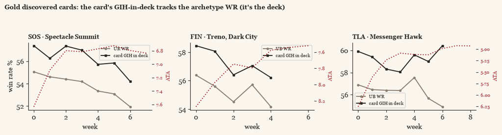

```python
def discovered_example(tag, gold):
    w, windows = weekly.weekly_panel(tag)
    w = w[w.ata.notna()]
    _, allf = weekly.find_movers(w, tag, min_gih=800)
    disc = allf[(allf.move < -0.4) & (allf.rho < -0.4)]
    cstats = data.card_stats(tag).set_index("name")
    import json
    sc = json.load(open(Path.cwd().parent / "data" / "raw" / "scryfall_oracle.json"))
    cid = {c["name"]: len(c.get("color_identity", [])) for c in sc}
    names = [n for n in disc.index if cid.get(n, 0) >= 2] if gold else [n for n in disc.index if cid.get(n, 0) <= 1]
    names = [n for n in names if cstats.loc[n].modal_deck and len(str(cstats.loc[n].modal_deck)) == 2] if False else names
    # pick the highest-volume one with a 2-color modal deck
    best = max(names, key=lambda n: cstats.loc[n].n_gih if n in cstats.index else 0, default=None)
    return best, windows

fig, axes = plt.subplots(1, 3, figsize=(11, 3))
for ax, tag in zip(axes, RETAIL):
    nm, windows = discovered_example(tag, gold=True)
    if nm is None:
        continue
    cd = weekly.card_by_archetype(tag, nm, windows)
    base = weekly.arch_baseline(tag, windows)
    d = cd.merge(base, on=["arch", "t"], how="left")
    a1 = d.groupby("arch").n_gih.sum().idxmax()
    da = d[d.arch == a1].sort_values("t")
    ax.plot(da.t, da.base * 100, "-o", color=FADE, ms=3, label=f"{a1} WR")
    ax.plot(da.t, da.card_gih * 100, "-s", color=INK, ms=3, label="card GIH in deck")
    w, _ = weekly.weekly_panel(tag); cw = w[w.name == nm].set_index("t")
    a2 = ax.twinx(); a2.plot(cw.index, cw.ata, ":", color=CRIM, lw=1.5); a2.invert_yaxis()
    a2.set_ylabel("ATA", color=CRIM, fontsize=8); a2.tick_params(labelcolor=CRIM, labelsize=7)
    ax.set_title(f"{NAMES[tag]} · {nm[:18]}", fontsize=9, fontweight="bold", loc="left")
    ax.legend(fontsize=7); ax.set_xlabel("week")
axes[0].set_ylabel("win rate %")
fig.suptitle("Gold discovered cards: the card's GIH-in-deck tracks the archetype WR (it's the deck)",
             x=0.01, ha="left", fontsize=10, fontweight="bold")
plt.tight_layout(rect=[0, 0, 1, 0.92]); plt.show()
```

## 7. Worked example: Aang priced like Teferi (Powered Cube)

"Taken like Teferi" is a policy bundle — position, deployment, deck, pilot. The headline: even after charging Aang the position penalty (from the cube's own lateness curve) and the deployment dilution, it still clears Teferi's GIH, because their deck contexts barely differ. Full estimand decomposition in `NOTES.md §1` / the original `aang_vs_teferi` analysis.

```python
t = data.card_table("CubePowered", "run3_2026-05-28")
aang = t[t.name == "Aang, Swift Savior"].iloc[0]
tef = t[t.name == "Teferi, Time Raveler"].iloc[0]
mu = (t.n_gp * t.gp_wr).sum() / t.n_gp.sum()
cells = data.aspicked("cube")
curve, _, _ = analysis.within_card(cells, "gih_wr", "n_gih")
pos = np.interp(aang.ata, curve.index, curve.values) - np.interp(tef.ata, curve.index, curve.values)
effect = aang.gih_wr - aang.gns_wr
gns_curve, _, _ = analysis.within_card(cells, "gns_wr", "n_gns")
gns_loss = np.interp(aang.ata, gns_curve.index, gns_curve.values) - np.interp(tef.ata, gns_curve.index, gns_curve.values)
gns_cf = aang.gns_wr - gns_loss
display(pd.DataFrame([
    {"card": "Aang (observed)", "ATA": round(aang.ata, 1), "play": f"{aang.pct_gp:.0%}", "GIH": f"{aang.gih_wr:.1%}"},
    {"card": "Aang priced like Teferi", "ATA": round(tef.ata, 1), "play": "~67%",
     "GIH": f"{gns_cf + effect * 0.9:.1%}–{gns_cf + effect:.1%}"},
    {"card": "Teferi (observed)", "ATA": round(tef.ata, 1), "play": f"{tef.pct_gp:.0%}", "GIH": f"{tef.gih_wr:.1%}"},
]))
print(f"format mean GIH {mu:.1%} — priced like Teferi, Aang still clears Teferi's {tef.gih_wr:.1%}.")
```

|  | card | ATA | play | GIH |
| --- | --- | --- | --- | --- |
| 0 | Aang (observed) | 9.1 | 60% | 61.7% |
| 1 | Aang priced like Teferi | 5.3 | ~67% | 60.5%–61.4% |
| 2 | Teferi (observed) | 5.3 | 80% | 59.3% |

```
format mean GIH 54.6% — priced like Teferi, Aang still clears Teferi's 59.3%.
```

## 8. Synthesis

Confounders catalog, hypotheses-and-verdicts table, and the full methods retrospective (what worked / what didn't): **`NOTES.md`**.